# Manual de identidad gráfica LANCIS

# Presentación

El presente manual es una guía de uso para la identidad institucional del Laboratorio Nacional de las Ciencias de la Sostenibilidad (LANCIS). Debe servir también, como punto de partida para aplicaciones ulteriores que se puedan desarrollar. No es la intención de este documento utilizar terminología rebuscada que confunda a quien lo consulte, sino brindar una referencia al alcance de cualquier persona que permita comprender con facilidad cómo debe ser usado el logotipo institucional.

# Introducción

## El enlace borromeo

Aunque en ocasiones se le llame *nudo* borromeo, se trata de un enlace, ya que está formado por más de un elemento. El enlace borromeo debe su nombre a la familia italiana que desde el siglo XV lo utilizó en su escudo de armas. El uso de este símbolo en la península italiana parece remontarse a un emblema de la ciudad de Cremona, de donde lo tomó Francesco Sforza para luego otorgarlo a la familia Borromeo (ca. 1450).

Al igual que muchas formas y símbolos de la humanidad, es posible encontrar enlaces de este tipo en figuras pertenecientes a distintas culturas y tiempos. El *Valknut,* por ejemplo, es un símbolo nórdico formado por tres triángulos entrelazados a manera de aros borromeos; se utilizó en Suecia desde el siglo IX.

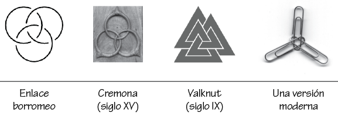

Este enlace tiene la particularidad de que un aro une a los otros dos, es decir, si retiramos uno, los otros dos dejan de estar unidos. Es por esto que se ha usado como representación de la *fuerza mediante la unión.*

# El logotipo del LANCIS

Aunque su forma se inspire en elementos orgánicos (guijarros, hojas, gotas de agua), el logotipo del LANCIS es completamente abstracto, sin embargo, retoma la forma topológica de los aros borromeos para aprovechar las múltiples alegorías e interpretaciones que pueden desprenderse de esta figura como símbolo de unión. En el ámbito de las Ciencias de la Sostenibilidad hay varias interpretaciones posibles (tres ámbitos: biológico, económico y social; tres actores: gobierno, sociedad y academia; así como un laboratorio inicialmete conformado por tres unidades de investigación).

Los colores se escogieron pensando en asociaciones con la naturaleza: verde y azul claro, incorporando además el azul oscuro distintivo de la UNAM, sede del LANCIS.

El logotipo, como ya dijimos, es una abstracción, todas estas interpretaciones no se deducen por sí solas, más bien surgen de nuestra propia visión institucional.

Como norma, se usarán dos versiones principales: el logotipo oficial (formado por el símbolo y el nombre) y la versión extendida con el nombre completo de la institución.

[figure not shown]

Una tercera versión, extendida vertical, se usará solo cuando la disposición horizontal no convenga a la composición.

[figure not shown]

# Elementos y terminología básica

El logotipo esta compuesto por dos elementos inseparables: el símbolo y la tipografía. Es importante comprender esta idea de unidad ya que nunca se presentan dichos elementos por separado.

[figure not shown]

En la versión extendida del logotipo, se utiliza además, una pleca vertical y otro elemento tipográfico que resulta de poner el nombre completo de la institución.

[figure not shown]

# Colores

Utilizamos cuatro colores, tres para cada uno de los aros y negro para la tipografía. Se proporcionan valores para los cuatro principales modelos de color.

[figure not shown]

La elección de cada modelo dependerá del destino final que se requiera. En general, el catálogo Pantone y el modelo CMYK (valores de cian, magenta, amarillo y negro), se usan en procesos de impresión; mientras que el sistema hexadecimal y RGB (rojo, verde, azul), sirven para desplegarse en pantalla.

# Proporciones

Mostramos las proporciones y la retícula de las tres versiones del logotipo, tomando como módulo *(x)* la altura de una mayúscula.

[figure not shown]

[figure not shown]

[figure not shown]

# Área de protección

El área de protección es el espacio mínimo que debe quedar libre alrededor del logotipo, esto con la finalidad de que se lea bien y visualmente no compita cuando se use junto con otros logotipos o elementos de diseño.

[figure not shown]

[figure not shown]

# Tamaño mínimo

Se refiere al tamaño mínimo en que deba reproducirse el logotipo para asegurar buena legibilidad, tanto en impreso como en pantalla. Se proporcionan los valores en centímetros y pixeles según cada caso.

[figure not shown]

# Fuentes tipográficas

El logotipo utiliza la fuente Cronos Pro distribuída por Adobe. Esta fuente cuenta con una amplia variedad de pesos de los cuales utilizamos solo tres: *Semibold Display* para el nombre, *Light* para las versiones extendidas y *Light Caption* para las versiones caladas.

[figure not shown]

El *track* se refiere al ajuste óptico utilizado en el espaciado de las letras.

## Fuentes auxiliares

Las fuentes auxiliares son las que utilizaremos en documentos y plantillas generados en el LANCIS. Se proponen dos fuentes auxiliares: Chaparral Pro distribuida por Adobe y Calibri de distribución gratuita con el sistema operativo Windows. Se utilizan principalmente los pesos *Light* para cuerpo de texto y *Semibold* o *Bold* para títulos.

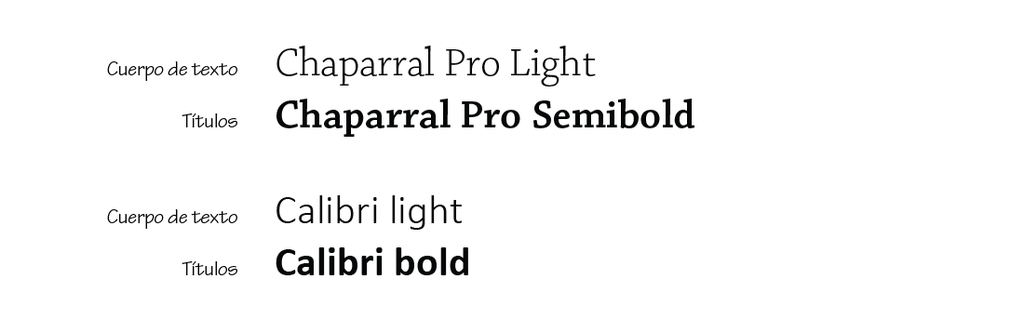

# Variantes permitidas

Se deberá privilegiar el uso de la versión en color sobre fondo blanco y de la versión extendida horizontal.

[figure not shown]

La versión extendida vertical, como ya se mencionó, será de uso excepcional y podrá usarse solo cuando así convenga a la composición.

[figure not shown]

En casos especiales que así lo requieran, se permitirá el uso de variantes en blanco sobre fondo oscuro (calados).

[figure not shown]

[figure not shown]

Se consideran también variantes monocromáticas en negro sobre fondo claro.

[figure not shown]

# Usos incorrectos

Parte importante de este manual consiste en especificar qué usos del logotipo **no** están permitidos. A continuación se muestran los casos más importantes:

- No usar los colores en escala de grises ni cambiar o modificar colores

[figure not shown]

- No modificar proporciones

[figure not shown]

- No usar el símbolo sin la tipografía.
- No inclinar

[figure not shown]

- No cambiar la posición de la tipografía o cambiar la fuente tipográfica

[figure not shown]

- No añadir elementos (como ornamentos, marcos, etc.) o agregar sombras o efectos

[figure not shown]

- No usar como patrón repetido o calar sobre un fondo que no sea contínuo

[figure not shown]